# Expected FA contract for 2019

2018-12-13

## 0. Table of Content

1. Data preprocessing
2. LASSO
3. Create a regression model
4. Applying the model
5. Conclusion

## Data preprocessing

## 1. Data preprocessing

## 1. Data preprocessing

[figure not shown]

[그림 1: NC 다이노스 양의지]

## 1. Data preprocessing

## 1. Data preprocessing

- Statiz (www.statiz.co.kr)
  - baseball_B - FA1218B1.csv
  - baseball_B2 - FA1218B2.csv
  - baseball_B3 - FA1218P2.csv
  - baseball_P - FA1218P1.csv
  - baseball_P2 - FA1218P2.csv
  - baseball_P3 - FA1218P3.csv

## LASSO

## 2. LASSO

## 2. LASSO

**LASSO?**

## 2. LASSO

**LASSO?**

- Associated with linear regression

## 2. LASSO

**LASSO?**

- Associated with linear regression
- One type of machine learning algorithm

## 2. LASSO

**LASSO?**

- Associated with linear regression
- One type of machine learning algorithm
- Penalization

## Create a regression model

## 3. Create a regression model

## 3. Create a regression model

```r
library(glmnet)
baseball_B2 <- read.csv("FA1218B2.csv", header = TRUE)
x <- model.matrix(aincome ~., baseball_B2)[,-1]
y <- baseball_B2$aincome
```

## 3. Create a regression model

**Data segmentation (train Vs. test)**

```r
set.seed(1)
train = sample(1:nrow(baseball_B2),40)
test = (-train)
ytest = y[test]
```

## 3. Create a regression model

**Find lambda with minimal MSE (Cross Validation)**

```r
for (i in 0:10) {
set.seed(1)
cv.lasso <- cv.glmnet(x[train,], y[train], alpha = 0.1*i)
lasso.coef = predict(cv.lasso, type = "coefficients",
                     s = cv.lasso$lambda.min)
lasso.prediction = predict(cv.lasso, s = cv.lasso$lambda.min,
                           newx = x[test,])
lasso.coef
cv.lasso$lambda.min
c <- cor(lasso.prediction, ytest)
d <- sqrt((mean(lasso.prediction - ytest)^2))
print(c)
print(d)
print(0.1*i)
}
```

## 3. Create a regression model

**Find lambda with minimal MSE (Cross Validation)**

```
##        [,1]
## 1 0.8470192
## [1] 1.220718
## [1] 0
##       [,1]
## 1 0.848287
## [1] 1.189253
## [1] 0.1
##        [,1]
## 1 0.8544699
## [1] 1.236822
## [1] 0.2
##        [,1]
## 1 0.8497116
## [1] 1.156382
```

[output cut: 29 more lines]

## 3. Create a regression model

**Find lambda with minimal MSE (Cross Validation)**

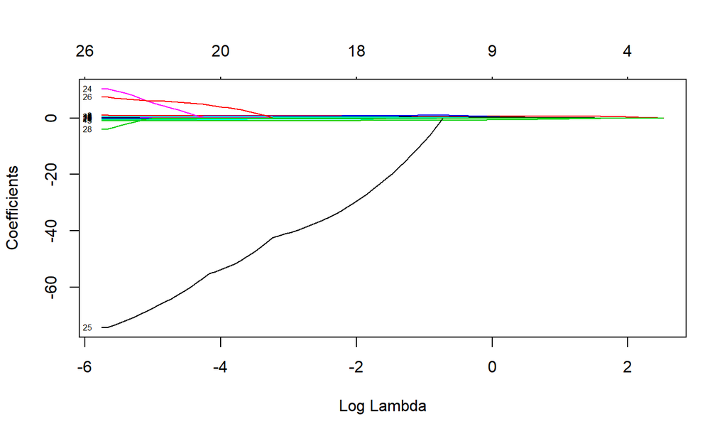

[output not shown]

[output not shown]

[output not shown]

```r
set.seed(1)
cv.lasso <- cv.glmnet(x[train,], y[train], alpha = 0.4)
plot(cv.lasso$glmnet.fit, xvar = "lambda", label=TRUE)
```

## 3. Create a regression model

**Create function (B)**

```
## 30 x 1 sparse Matrix of class "dgCMatrix"
##                         1
## (Intercept)  41.952822615
## tWAR          0.146467601
## WAR           0.822372287
## age          -0.846769174
## Pscore        0.754642950
## G            -0.045571505
## PA            .
## AB            .
## R             0.041278520
## X1B           0.015224423
## X2B           0.166905855
## X3B          -0.385780637
## HR            0.015576814
## TB            0.009989264
## RBI           .
## SB            0.046081215
## CS            .
## BB           -0.034498930
## HBP           0.266548441
## IBB           0.463737742
## SO           -0.001831735
## GDP          -0.204734559
## SH            .
## SF            0.390214059
## AVG           .
## OBP         -36.229243371
## SLG           .
## OPS           .
## wOBA          .
## wRC.          .
```

## 3. Create a regression model

**Create function (B)**

```r
FAB <- function(FA) {
  d <- with(FA,
            b[1]
            + b[2] * tWAR + b[3] * WAR
            + b[4] * age + b[5] * Pscore
            + b[6] * G + b[9] * R
            + b[10] * X1B + b[11] * X2B
            + b[12] * X3B
            + b[13] * HR
            + b[14] * TB
            + b[16] * SB
            + b[18] * BB + b[19] * HBP
            + b[20] * IBB + b[21] * SO
            + b[22] * GDP + b[24] * SF
            + b[26] * OBP
            )
}
```

## Applying the model

## 4. Applying the model

## 4. Applying the model

```r
as.character(baseball_B1[,1])
```

```
##  [1] "양의지" "모창민" "최정"   "이재원" "송광민" "이용규" "최진행"
##  [8] "김민성" "김상수" "박용택" "박경수"
```

```r
FABat <- FAB(baseball_B1)
FABat
```

```
##  [1] 23.206991  5.671174 23.418748 14.521925  8.999328 13.863788  3.388131
##  [8] 14.069173 13.275153 11.009418  9.619859
```

## 4. Applying the model

```r
as.character(baseball_P1[,1])
```

```
## [1] "이보근" "윤성환" "노경은" "금민철"
```

```r
FAPit <- FAP(baseball_P1)
FAPit
```

```
## [1] 10.975032  6.155767 13.169065 12.754598
```

## 4. Applying the model

```r
as.character(baseball_B1[,1])
```

```
##  [1] "양의지" "모창민" "최정"   "이재원" "송광민" "이용규" "최진행"
##  [8] "김민성" "김상수" "박용택" "박경수"
```

```r
FABat2 <- FAB2(baseball_B1)
FABat2
```

```
##  [1] 3.833865 3.050848 3.662250 3.736815 2.899648 3.458541 2.826888
##  [8] 3.499480 3.815451 2.450391 3.173694
```

## 4. Applying the model

```r
as.character(baseball_P1[,1])
```

```
## [1] "이보근" "윤성환" "노경은" "금민철"
```

```r
FAPit2 <- FAP2(baseball_P1)
FAPit2
```

```
## [1] 3.299488 3.297012 3.300802 3.303397
```

## Conclusion

## 5. Conclusion

## 5. Conclusion

```r
as.character(baseball_B1[,1])
```

```
##  [1] "양의지" "모창민" "최정"   "이재원" "송광민" "이용규" "최진행"
##  [8] "김민성" "김상수" "박용택" "박경수"
```

```r
round(FABat2)
```

```
##  [1] 4 3 4 4 3 3 3 3 4 2 3
```

```r
FABat * round(FABat2)
```

```
##  [1] 92.82797 17.01352 93.67499 58.08770 26.99798 41.59136 10.16439
##  [8] 42.20752 53.10061 22.01884 28.85958
```

## 5. Conclusion

```r
as.character(baseball_P1[,1])
```

```
## [1] "이보근" "윤성환" "노경은" "금민철"
```

```r
FAPit2 <- FAP2(baseball_P1)
round(FAPit2)
```

```
## [1] 3 3 3 3
```

```r
FAPit * round(FAPit2)
```

```
## [1] 32.92510 18.46730 39.50719 38.26379
```

## 5. Conclusion

**Reality vs Expectation**

## 5. Conclusion

**Reality vs Expectation**

- 양의지 [4년 125억원 vs 4년 93억원]
- 모창민 [3년 20억원 vs 3년 17억원]
- 최정 [6년 106억원 vs 4년 94억원]
- 이재원 [4년 69억원 vs 4년 58억원]